# Lab Sheet 4

STAT260, University of Otago

Sem. 2, 2021

# Task 1

The data that we will use today is a random sample of 1985 current population survey (CPS) undertaken in the US. The data are in `cps.csv`. There are 534 observations with variables:

- `Education`: the number of years of education
- `South`: Indicator variable for Southern region (1 = Southern, 0 = not Southern)
- `Sex`: Indicator variable for sex (1 = female, 0 = male)
- `Experience`: Number of years of work experience
- `Union`: Indicator variable for union membership (1 = member, 0 = not member)
- `Wage`: dollars per hour
- `Age`: age (years)
- `Race`: 1 = other, 2 = Hispanic, 3 = white
- `Occupation`: 1 = management, 2 = sales, 3 = clerical, 4 = service, 5 = professional, 6 = other
- `Sector`: 0 = other, 1 = manufacturing, 2 = construction
- `Marr`: Indicator variable for marital status (1 = married, 0 = not married)

Call these data into R in the space below. Look at the first few observations.

*Answer:*

```r
data <- read.csv("./cps.csv", header = TRUE)
head(data)
```

|  | Education | South | Sex | Experience | Union | Wage | Age | Race | Occupation | Sector | Marriage |
| --- | --- | --- | --- | --- | --- | --- | --- | --- | --- | --- | --- |
| 1 | 8 | 0 | 1 | 21 | 0 | 5.10 | 35 | 2 | 6 | 1 | 1 |
| 2 | 9 | 0 | 1 | 42 | 0 | 4.95 | 57 | 3 | 6 | 1 | 1 |
| 3 | 12 | 0 | 0 | 1 | 0 | 6.67 | 19 | 3 | 6 | 1 | 0 |
| 4 | 12 | 0 | 0 | 4 | 0 | 4.00 | 22 | 3 | 6 | 0 | 0 |
| 5 | 12 | 0 | 0 | 17 | 0 | 7.50 | 35 | 3 | 6 | 0 | 1 |
| 6 | 13 | 0 | 0 | 9 | 1 | 13.07 | 28 | 3 | 6 | 0 | 0 |

# Task 2

We are interested in how wages depend on experience. Produce a scatterplot of wages (y-axis) against experience (x-axis). Ensure you label both the x and y axes (you should do this for all plots you make). What are your impressions on any relationship between wages and experience?

*Answer:*

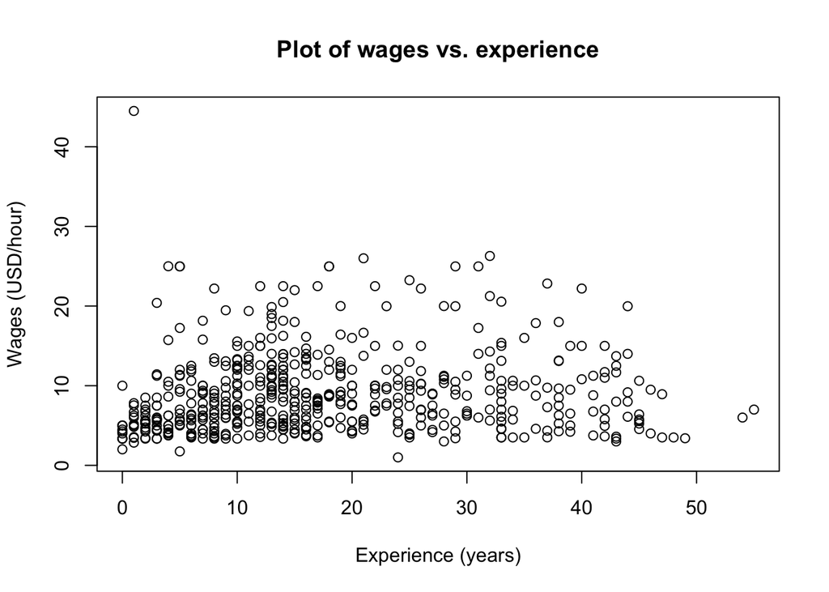

```r
plot(x = data$Experience, y = data$Wage, main = "Plot of wages vs. experience", xlab = "Experience (years)", ylab  = "Wages (USD/hour)")
```

# Task 3

Produce a plot comparing wage to experience, where we allow the colour to depend on each individuals race. HINT: Note that the race variable is already in numeric form (not a factor like the example in the lecture).

*Answer:*

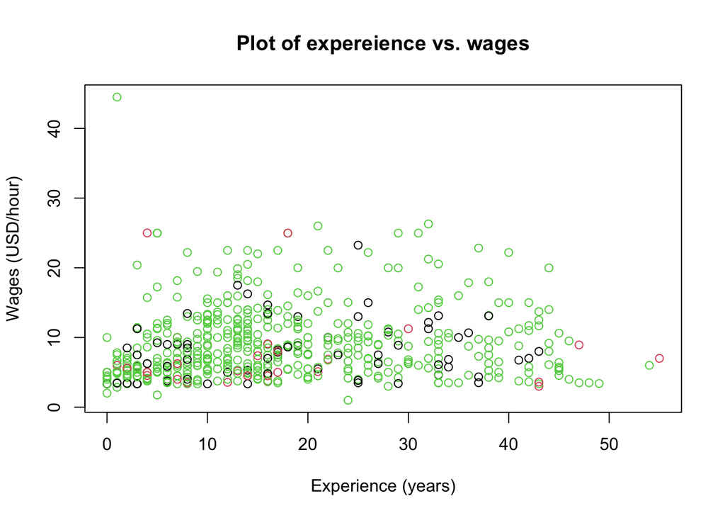

```r
plot(data$Experience, data$Wage, col = data$Race, main = "Plot of expereience vs. wages", xlab = "Experience (years)", ylab = "Wages (USD/hour)")
```

# Task 4

Redraw the plot from Task 3, this time, include a legend. HINT: Since the race variable is already numeric we must specify a vector giving the group names. This can be done with `c("Other","Hispanic","White")` (look at the description of the data above to see how we know the labels have to be in that specific order).

*Answer:*

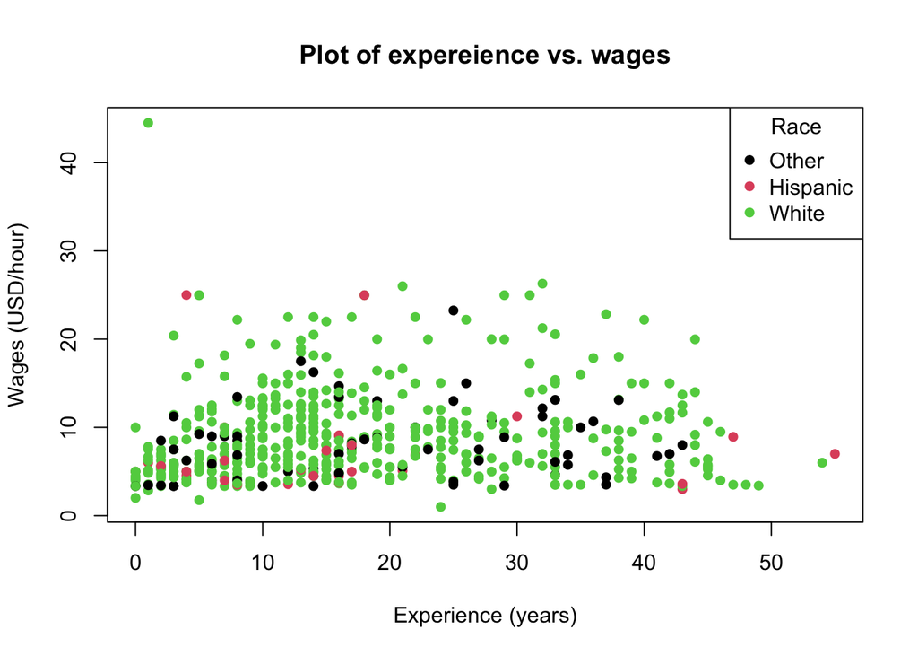

```r
plot(data$Experience, data$Wage, col = data$Race, main = "Plot of expereience vs. wages", xlab = "Experience (years)", ylab = "Wages (USD/hour)", pch = 16)
legend("topright", legend = c("Other", "Hispanic", "White"), col = 1:3, pch = 16, title = "Race")
```

******

# Task 5

Produce another new plot of wage against experience. In this version, the sex of the individual should be used as a point character. Include an appropriate legend with appropriate labels. Hint: `Sex` is already numeric and coded with 0s and 1s. To use it as a character point we instead need it coded as 1s and 2s – how can you easily achieve this?

*Answer:*

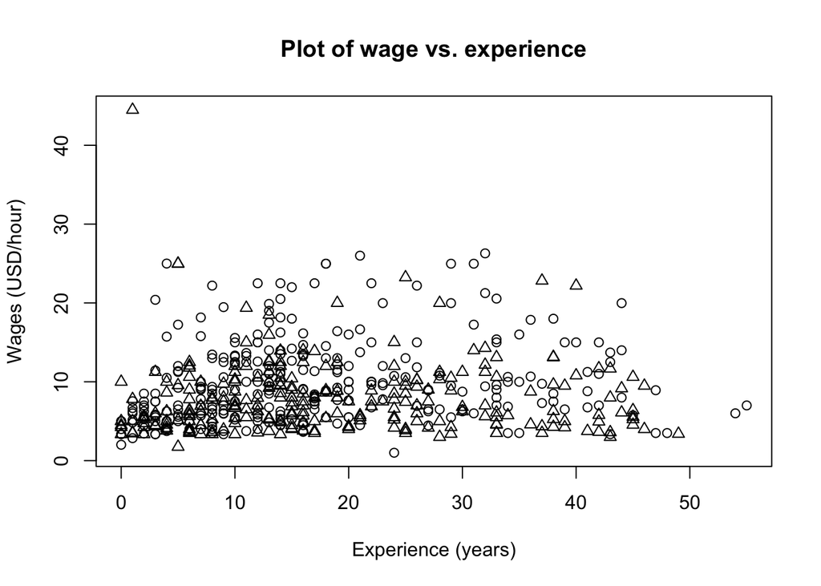

```r
data$Sex <- data$Sex + 1
plot(data$Experience, data$Wage, main = "Plot of wage vs. experience", xlab = "Experience (years)", ylab = "Wages (USD/hour)", pch = data$Sex)
```